# Projection EpiVAR pour le suivi de l’épidémie de Covid en France

Pierre Aldama

2023-11-27

### Description du modèle

EpiVAR est un modèle économétrique de type Vecteur Auto-Regressif (VAR) pour la prévision à court-terme de la dynamique de l’épidémie de Covid en France, à l’échelle nationale. Il est estimé par MCO sur données journalières pour le taux de reproduction effectif, le nombre de cas confirmés, d’hospitalisation, de lits occupés en soins critiques et de décès hospitaliers. Il s’écrit tel que:

$$Y_t = A_1 Y_{t-1} + ... + A_p Y_{t-p} + u_t$$
avec le vecteur des variables endogènes :
$$Y_t = \begin{pmatrix} \Delta \log R_t \\ \Delta
\log Cas_t\\ \Delta \log Hosp_t \\ \Delta \log Rea_t \\ \Delta \log
Décés_t \end{pmatrix}$$
Le vecteur des résidus $u_t$ est supposé être i.i.d. tel que $\mathbb{E}[u_t] = 0$, $\mathbb{E}[u_tu_t']=\Sigma$ et $\mathbb{E}[u_tu_{t-1}']=0$. On retient une spécification avec $p=28$ retards. [^1]

On choisir de ne pas inclure un vecteur de constantes dans la mesure où l’état-stationnaire de l’épidémie implique une stabilité de l’ensemble de ces variables (i.e. $\Delta \log x_t = 0$); en revanche, dans la mesure où le modèle est écrit en différence-première, nous ne faisons pas d’hypothèse sur le *niveau* des variables du VAR.

#### Fonctions impulsions-réponses et décomposition de la variance de l’erreur de prévision

Les deux figures suivantes donnent un aperçu des propriétés du modèles EpiVAR en réponse à des chocs orthogonalisés (par décomposition de Cholesky de la matrice de variance-covariance $\Sigma$). Les fonctions d’impulsions-réponses montrent la réponse cumulée de chacune des variables (en colonnes) à des chocs sur chacune de ces variables (en lignes).

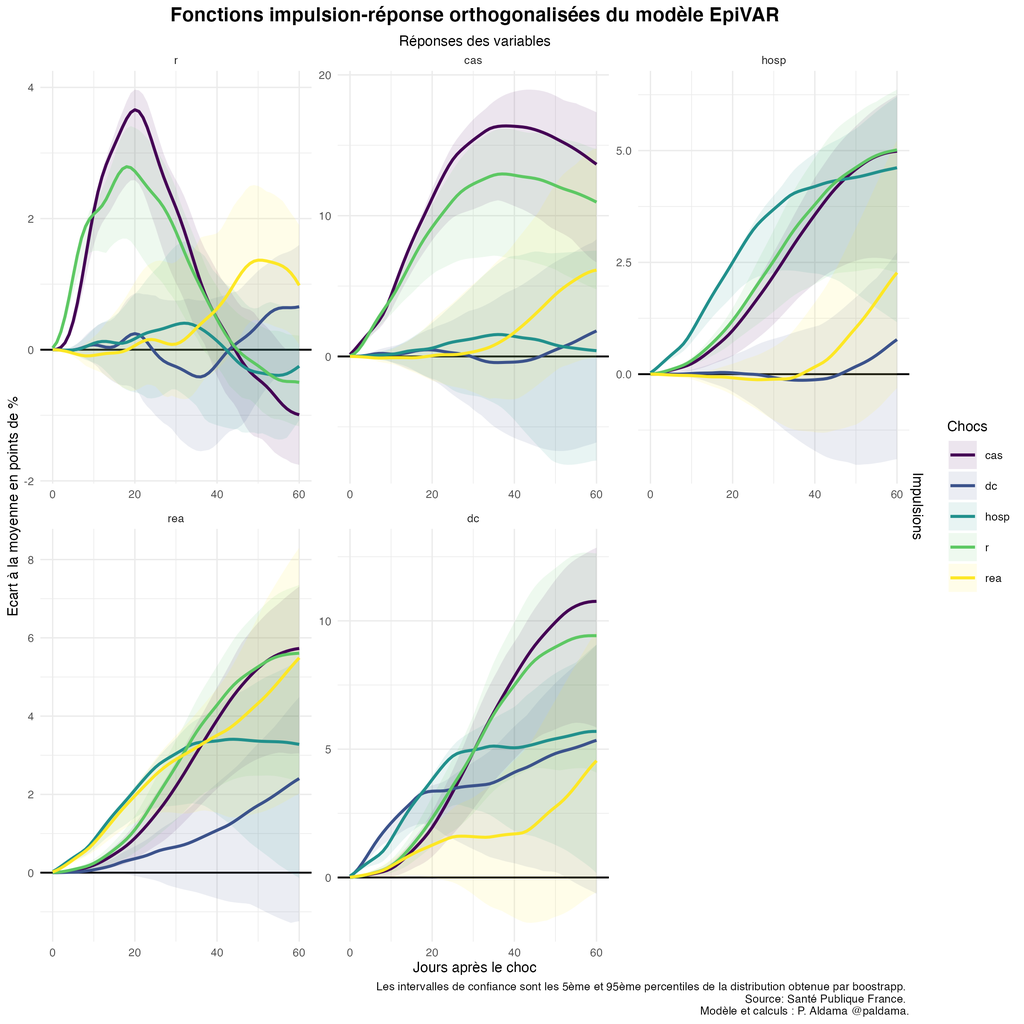

Une autre façon de considérer ces propriétés est de calculer la décomposition de la variance de l’erreur de prévision à partir de ces fonctions impulsions-réponses, pour chacun de ces chocs.

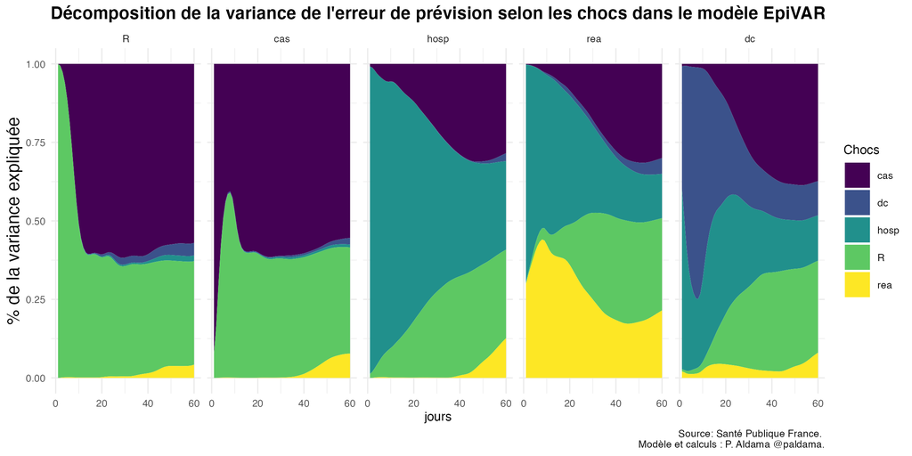

### Préparation des données

On commence tout d’abord par appliquer la correction des jours fériés proposées par Santé Publique France.

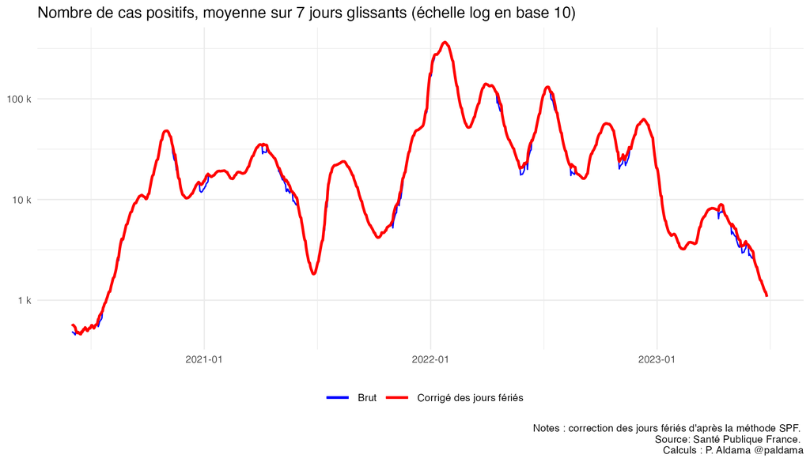

On calcule ensuite le taux de reproduction effectif à partir du package EpiEstim, car la série temporelle du taux de reproduction effectif fournie par SPF s’arrête plus tôt que celle du nombre de cas confirmés. On calcule un taux de reproduction sous l’hypothèse d’une moyenne de l’intervalle sériel $\mu = 5.19$ et un écart-type $\sigma = 0.42$, basé sur une méta-analyse des estimations disponibles.[^2] Pour ce calcul, on se base sur la série de cas confirmés en moyenne mobile sur 7 jours et corrigée des jours fériés.

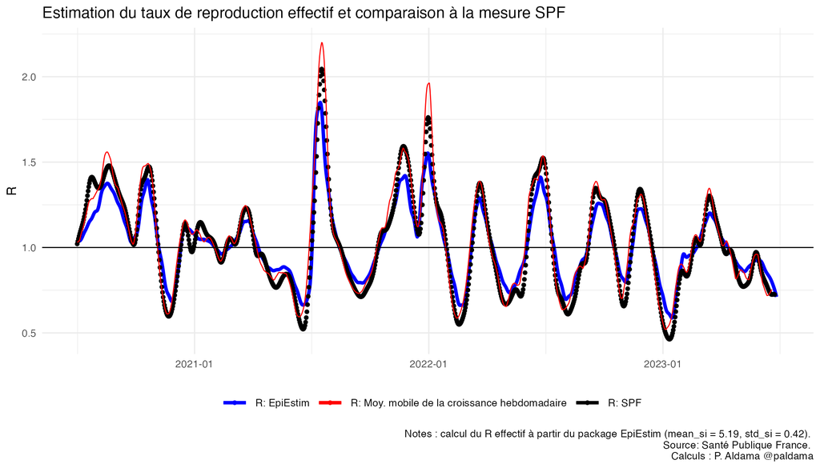

Enfin, on opère un double lissage de l’ensemble des séries restantes, d’abord en calculant la moyenne mobile sur les 7 derniers jours, puis par des regressions LOESS des moyennes mobiles elle-mêmes.[^3]

### Projections

On estime ensuite le modèle sur échantillon complet (*full sample*) et sur un échantillon réduit de 2 semaines (*out-of-sample*) pour produire deux projections.

- La première utilise toute l’information disponible à la dernière date pour laquelle on dispose d’observation pour chacune des variables.
- La seconde n’utilise pas les deux dernières semaines d’observations pour évaluer ce qu’aurait donné une projection passée.[^4]

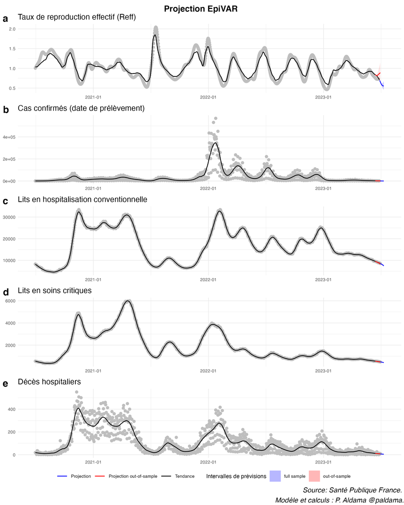